# Tarea 14

Mario Becerra 124362

03/05/2015

```r
library(dplyr)
```

```r
library(ggplot2)
library(ggthemes)
library(GGally)
library(rgdal)
library(knitr)
library(gstat)
library(geoR)
knitr::opts_chunk$set(warning=FALSE, message=FALSE, cache=TRUE)
ggthemes_data$colorblind <- append(ggthemes_data$colorblind, "#80f7e9")
assignInNamespace("ggthemes_data", ggthemes_data, ns="ggthemes")
```

```r
theme_nothing <- function(base_size = 12, base_family = "Helvetica")
  {
  theme_bw(base_size = base_size, base_family = base_family) %+replace%
      theme(
            #legend.text=element_blank(),
            axis.text.x =  element_blank(),
            axis.text.y =  element_blank(),
            axis.title.x=  element_blank(),
            axis.title.y=  element_blank(),
            rect             = element_blank(),
            line             = element_blank()
            #text             = element_blank(),
            #axis.ticks.margin = unit(0, "lines")
           )
  }
```

La base de datos “BatonRouge.txt” contiene la información de la venta de 50 casas habitación en Baton Rouge Louisiana. El objetivo es predecir el precio de venta en escala logarítmica para una casa con características dadas.

```r
baton <- read.table('baton.txt', header=TRUE, colClasses=c('numeric', 'integer', 'integer', 'integer', 'factor', 'factor', 'factor', 'numeric', 'numeric', 'numeric', 'numeric'))
baton_sh <- readOGR('./tl_2013', 'tl_2013_22033_edges')
```

```
## with 30731 features and 31 fields
## Feature type: wkbLineString with 2 dimensions
```

```r
baton_f <- fortify(baton_sh)
save(baton_f, file='./Out/baton_f.RData')
```

Las casas en el mapa se ven así:

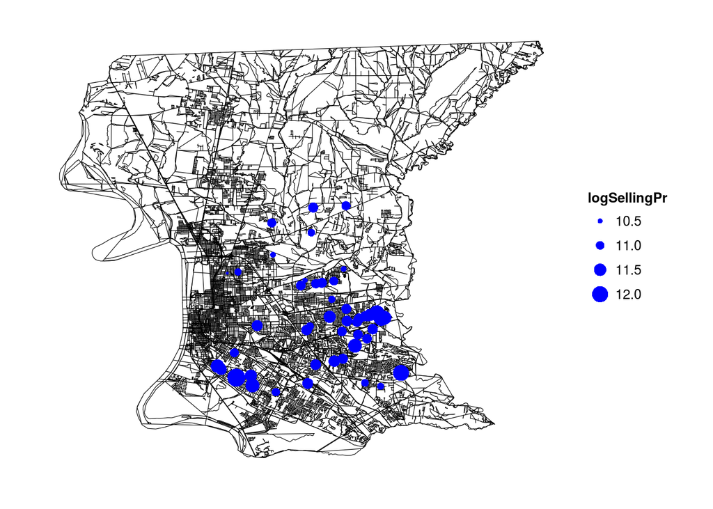

```r
load('./Out/baton_f.RData')
ggplot() +
  geom_polygon(data=baton_f, aes(long, lat, group=group), colour='black', fill='white', size=0.2) +
  geom_point(data=baton, aes(x=Longitude, y=Latitude, size=logSellingPr), colour='blue', inherit.aes=FALSE) +
  coord_fixed() + theme_nothing()
```

Ajustamos un primer modelo lineal para el precio de las casas usando como predictores: el área habitable (LivingArea), edad  
(Age), otra área (OtherArea) y número de baños (Bathrooms).

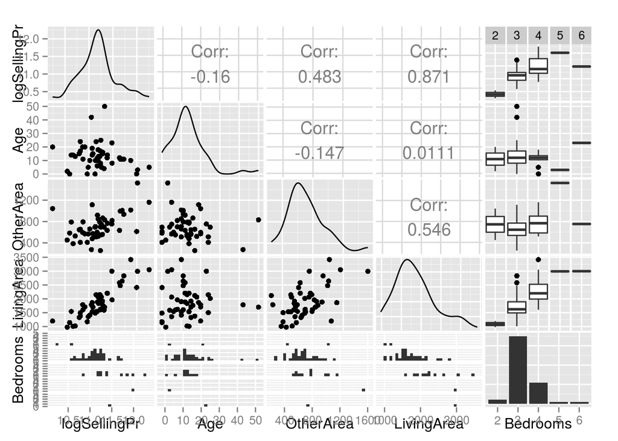

```r
ggpairs(baton[,c('logSellingPr', 'Age', 'OtherArea', 'LivingArea', 'Bedrooms')])
```

```r
mod1 <- lm(logSellingPr ~ Age + Bathrooms + OtherArea +LivingArea, data=baton)
summary(mod1)
```

```
##
## Call:
## lm(formula = logSellingPr ~ Age + Bathrooms + OtherArea + LivingArea,
##     data = baton)
##
## Residuals:
##      Min       1Q   Median       3Q      Max
## -0.46587 -0.09862 -0.00339  0.10734  0.51428
##
## Coefficients:
##               Estimate Std. Error t value Pr(>|t|)
## (Intercept)  1.010e+01  1.377e-01  73.335  < 2e-16 ***
## Age         -7.002e-03  3.072e-03  -2.279   0.0276 *
## Bathrooms2   2.159e-02  1.051e-01   0.206   0.8381
## Bathrooms3  -1.400e-01  1.927e-01  -0.726   0.4715
## OtherArea   -7.228e-06  1.459e-04  -0.050   0.9607
## LivingArea   6.301e-04  6.819e-05   9.241  7.2e-12 ***
## ---
## Signif. codes:  0 '***' 0.001 '**' 0.01 '*' 0.05 '.' 0.1 ' ' 1
##
## Residual standard error: 0.1887 on 44 degrees of freedom
## Multiple R-squared:  0.7931, Adjusted R-squared:  0.7696
## F-statistic: 33.73 on 5 and 44 DF,  p-value: 5.359e-14
```

Ahora veamos los residuales en el mapa.

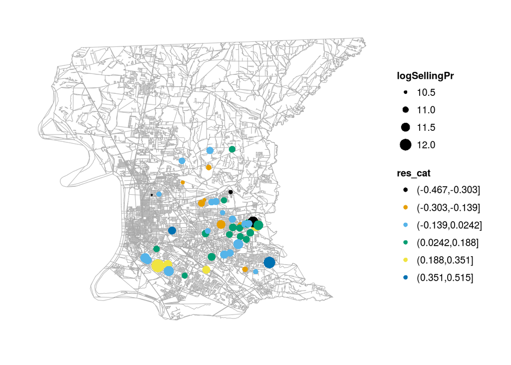

```r
baton$res <- mod1$residuals
baton$res_cat <- cut(baton$res, 6)

ggplot() +
  geom_polygon(data=baton_f, aes(long, lat, group=group), colour='dark grey', fill='white', size=0.2) +
  geom_point(data=baton, aes(x=Longitude, y=Latitude, size=logSellingPr, colour=res_cat), inherit.aes=FALSE) +
  coord_fixed() + scale_colour_colorblind() + theme_nothing()
```

Ajustemos el semivariograma empírico para los precios.

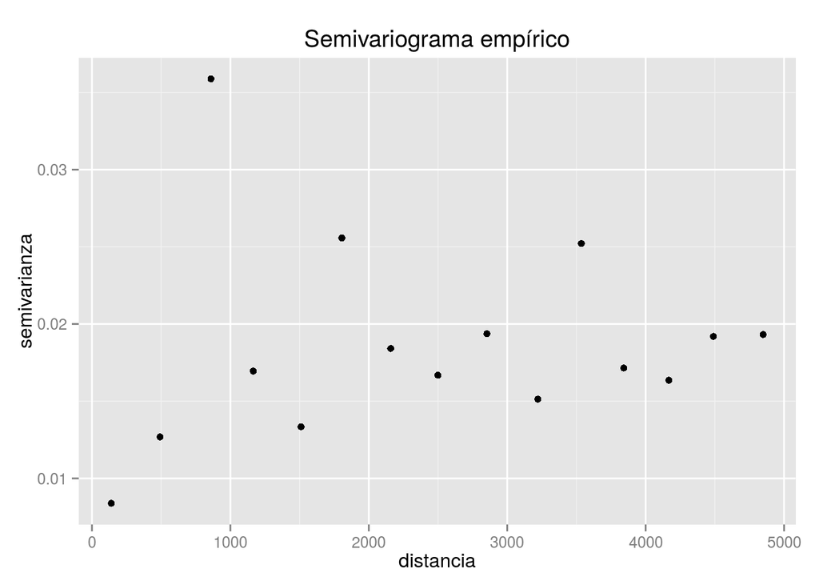

```r
baton.data <- data.frame(x = baton$Easting, y = baton$Northing, res = baton$res)
coordinates(baton.data)=~x+y
emp.variog <- variogram(res ~ 1, baton.data, cutoff = 5000)

ggplot(emp.variog, aes(x = dist, y = gamma)) +
  geom_point() +
  labs(title = expression("Semivariograma empírico"), x = "distancia", y = "semivarianza")
```

Ahora un semivariograma paramétrico (esférico).

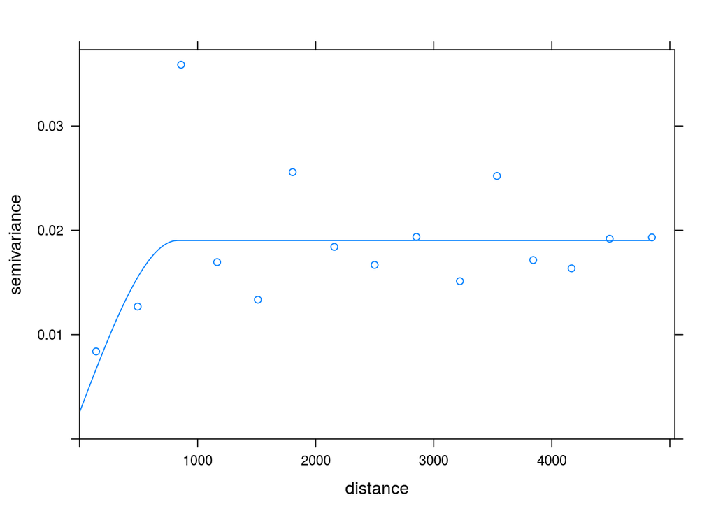

```r
sph.variog <- fit.variogram(emp.variog, vgm(psill=0.015, model="Sph", range = 1200, nugget = 0.008),fit.method = 2)
plot(emp.variog, sph.variog)
```

Usaremos las estimaciones del paso anterior (mínimos cuadrados ponderados) como valores iniciales de los parámetros $\sigma^2$, $\phi$, $\tau^2$, obtendremos las estimaciones de máxima verosimilitud restringida (REML) para los coeficientes del modelo y para los parámetros de la función de covarianza.

```r
sigma2.sph <- sph.variog$psill[2]
phi.sph <- sph.variog$range[2]
tau2.sph <- sph.variog$psill[1]
dist.vec <- emp.variog$dist # vector de distancias

baton.geo <- as.geodata(baton, coords.col = c(10,11), data.col = 1, covar.col=c(2,3,4,6))
baton.reml <- likfit(baton.geo, trend = ~ baton$LivingArea + baton$OtherArea + baton$Age + baton$Bathrooms, cov.model="spherical",
  ini=c(sigma2.sph, phi.sph), nugget = tau2.sph, fix.nugget = FALSE, lik.met="REML")
```

[output not shown]

```r
data.frame(Método = c("Inicial","REML"),
  sigma2 = c(sigma2.sph, baton.reml$sigmasq),
  phi = c(phi.sph, baton.reml$phi),
  tau2 = c(tau2.sph, baton.reml$tausq))
```

```
##    Método     sigma2      phi        tau2
## 1 Inicial 0.01646907 829.2128 0.002553752
## 2    REML 0.03611794 602.8661 0.000000000
```

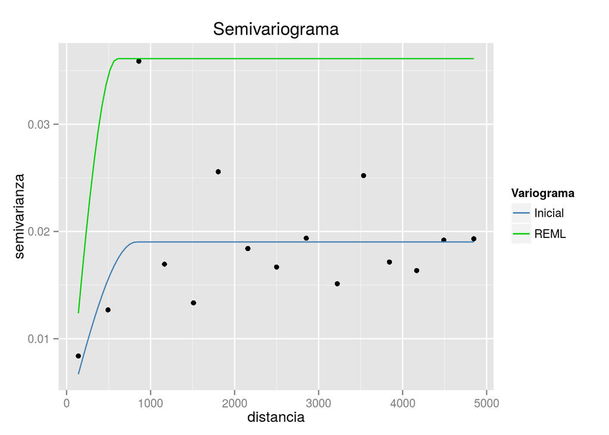

```r
sph.variog <- function(sigma2, phi, tau2, dist){
  n <- length(dist)
  sph.variog.vec <- rep(0,n)
  for(i in 1:n){
    if(dist[i] < phi){
      sph.variog.vec[i] <- tau2 + (sigma2 * (((3 * dist[i]) / (2 * phi)) -
          ((dist[i] ^ 3)/(2 * (phi ^ 3)))))
    }
    if(dist[i] >= phi){
      sph.variog.vec[i] <- tau2 + sigma2
    }
  }
  return(sph.variog.vec)
}

ggplot(data=emp.variog, aes(x = dist, y = gamma)) + geom_point() +
  labs(title = expression("Semivariograma"), x = "distancia", y = "semivarianza") +
  stat_function(fun = sph.variog, args = list(sigma2 = baton.reml$sigmasq, phi = baton.reml$phi, tau2 = baton.reml$tausq),
                  aes(colour = "REML")) +
  stat_function(fun = sph.variog, args = list(sigma2 = sigma2.sph, phi = phi.sph, tau2 = tau2.sph),
                  aes(colour = "Inicial")) +
  scale_colour_manual("Variograma", values = c("steelblue", "green3"))
```

```r
sigma2.reml <- baton.reml$sigmasq
phi.reml <- baton.reml$phi
tau2.reml <- baton.reml$tausq

x0=680660
y0=3376363
loc.uk <- matrix(c(x0,y0), nrow=1, ncol=2)

LivingArea <- 935
OtherArea <- 332
Age <- 25
Bathrooms <- 1

kc.uk.control <- krige.control(type.krige = "ok", trend.d = ~ baton$LivingArea + baton$OtherArea + baton$Age + baton$Bathrooms,
  trend.l = ~~935+332+25+1,
  cov.model = "spherical", cov.pars=c(sigma2.reml, phi.reml), nugget = tau2.reml)
kc.uk.s0 <- krige.conv(baton.geo, locations = loc.uk, krige = kc.uk.control)

kc.uk.control <- krige.control(type.krige = "ok", trend.d = ~ LivingArea + OtherArea + Age + Bathrooms,
  trend.l = ~935+332+25+1,
  cov.model = "spherical", obj.model=baton.reml)
kc.uk.s0 <- krige.conv(baton.geo, locations = loc.uk, krige = kc.uk.control)

kc.uk.control <- krige.control(type.krige = "ok", trend.d = ~ baton$LivingArea + baton$OtherArea + baton$Age + baton$Bathrooms,
  trend.l = ~ LivingArea + OtherArea + Age + Bathrooms,
  cov.model = "spherical", cov.pars=c(sigma2.reml, phi.reml), nugget = tau2.reml)
kc.uk.s0 <- krige.conv(baton.geo, locations = loc.uk, krige = kc.uk.control)
```